# Project_1_draft_2

```python
import numpy as np
import matplotlib.pyplot as plt
import math
```

```python
# Constants
step_size = 0.1   # the x step between y values
x_i = 0           # the initial value input
y_i = 2           # the initial value output
start_point = 0   # start calculating at this x value
end_point = 5     # stop calculating when you reach this

# note: keep x_i and start point separate,
#       you might want them to be so later
```

## Problem:

Suppose that we found a volatile substance that we have placed in a sealed container. We know that molecules leave the surface at a rate 5 times the area of the surface and return at a rate 3 times the amount which has evaporated. Assume that this substance is spread evenly to a depth of 2mm over the bottom of a closed box that is 10cm by 5cm. Find a equation to model the depth of the substance at any point in time. Time is in hours.

## Differential Equation:

Where:

- $\frac{dE}{dt}$: The differential of some function $E(t)$, which gives the amount of substance in mm$^3$ evaporated at $t$ hours.
- $5000$: The surface area of the substance in mm$^2$.
- $3E$: The rate of condensation, proportional to $E(t)$.

## Solution:

Let $E(t)=E_1(t)\cdot u(t)$

Where:

- $E_1(t)$ is a solution to the homogeneous differential equation $E'(t)+3E(t)=0$
- $u(t)$ is a solution to the differential equation $u'(t)=\frac{5000}{E_1(t)}$

$E'(t)+3E(t)=0$ is a separable linear differential equation, giving $E_1(t)=e^{-3t}$

$u'(t)=5000e^{3t}$ is a separable differential equation, giving $u(t)=\frac{5000e^{3t}}{3}+5000C$

By substitution:

$E(t)=\frac{5000}{3}+5000Ce^{-3t}$

Knowing $E(0)=0$, $C=-\frac{1}{3}$, giving the solution:

$E(t)=(\frac{5000}{3})(1-e^{-3t})$

As the liquid and gaseous substance have a linear relationship, the volume of remaining liquid may be obtained by:

$V(t)=V_i-E(t)$

Where:

- $V(t)$ is some function which gives remaining liquid volume in mm$^3$ at $t$ hours
- $V_i$ is the initial liquid volume in mm$^3$

Height of the liquid is given by:

$H(t)=\frac{V(t)}{S(t)}$

Where:

- $H(t)$ is some function which gives the height of the substance in mm at $t$ hours
- $S(t)$ is some function which gives the surface area in mm$^2$ at $t$ hours

Since $S(t)\equiv 5000$, $H(t)$ can be expressed as:

$\begin{aligned} H(t)&=\frac{V(t)}{5000}\\ \\&=\frac{ 10000 - E(t) }{ 5000 }\end{aligned}$

After substitution:

$H(t)=\frac{5+e^{-3t}}{3}$

## Solution Plot:

```python
def sol(x):
    return (5 + np.e**(-3 * x)) / 3
```

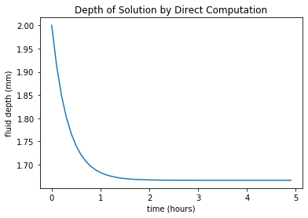

```python
# set the resolution for direct calculation
t = np.arange(start_point, end_point, .1)

# TODO
# screw with the axes on this graph
# do they need better scale?

plt.title('Depth of Solution by Direct Computation')
plt.xlabel('time (hours)')
plt.ylabel('fluid depth (mm)')
plt.plot(t,sol(t))
```

## Approximation using Euler's Method:

```python
# Define the derivative of our function
def dydx(x,y):
    return -1 * math.e**(-3*x)
```

```python
# Euler's method coded as a definition. Note that we have control here over h.
def eulers(x, y, h):
    return y + dydx(x,y) * h
```

```python
Appx_X = [x_i] # initiate our independent variable list
Appx_Y = [y_i] # outputs while go here during the loop

# create an x value you can operate on
# this should equal the starting x value
current_point = start_point

# the solution dictates that the
# initial estimate will equal y_i
estimate = y_i

# iterate until our next step would be
# at or past the desired stopping point
while current_point + step_size < end_point:
    estimate = eulers(current_point, estimate, step_size)
    current_point += step_size
    Appx_Y.append(estimate)
    Appx_X.append(current_point)
```

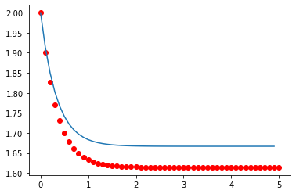

```python
plt.plot(Appx_X,Appx_Y, 'ro')
plt.plot(t, sol(t))
```

## Analysis of approximation errors:

```python
# you need to write some python here
# maybe check time to run vs the two
# also check how far off approx is from real

# initialize a list for correct outputs
correct = []

# initialize a list to contain errors
errors = []

# populate correct values
for value in Appx_X:
    actual = sol(value)
    correct.append(actual)

for actual, estimate in zip(correct, Appx_Y):
    difference = actual - estimate
    errors.append(difference)
```

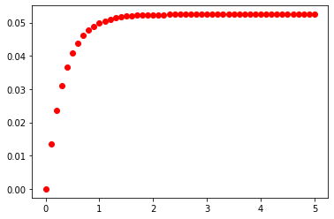

```python
plt.plot(Appx_X, errors, 'ro')
```

```python
# this is pretty easy, right?
# equil is reached in a couple hours
```